# Case Study: Bellabeat

### Calories v. Hours Slept

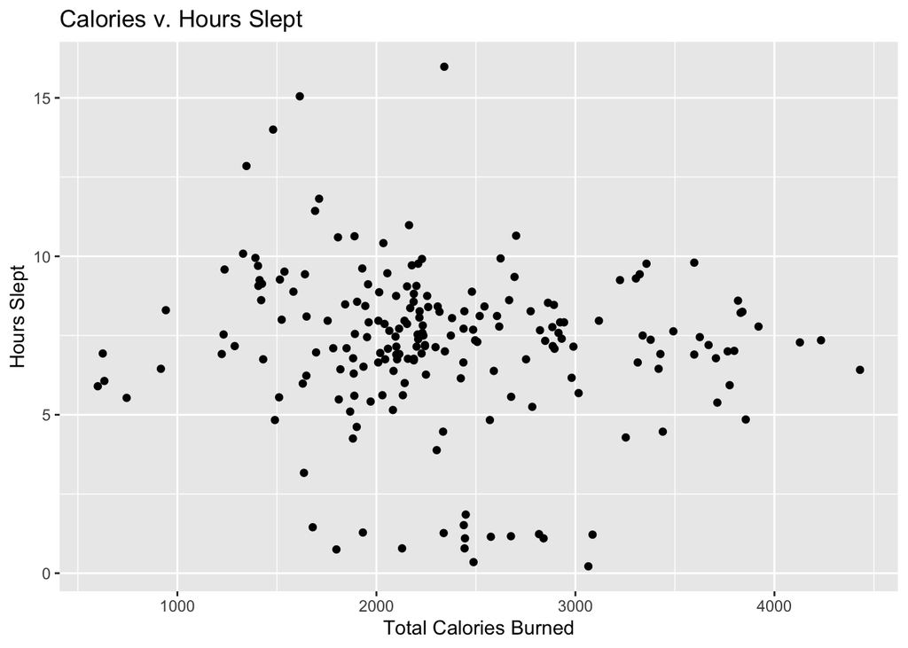

```r
ggplot(combineddata)+
  geom_point(aes(x=Calories, y=hours))+
  ggtitle("Calories v. Hours Slept")+
  xlab("Total Calories Burned")+
  ylab("Hours Slept")
```

```r
# Correlation Test
cor.test(combineddata$Calories,combineddata$hours, method=c('pearson'))
```

```
##
##  Pearson's product-moment correlation
##
## data:  combineddata$Calories and combineddata$hours
## t = -1.6646, df = 197, p-value = 0.09759
## alternative hypothesis: true correlation is not equal to 0
## 95 percent confidence interval:
##  -0.25272051  0.02167465
## sample estimates:
##        cor
## -0.1177703
```

There is no significant correlation between total calories burned per day and hours slept per day.

## Findings and Recommendations:

#### Recommendations:

By applying this FitBit data to the Bellabeat customer base, there are several areas to focus marketing strategies. Marketing strategies to increase awareness of their health habits may increase device usage.

Since the only available data is direct information from smart watch bioinformatics, it is difficult to make accurate recommendations on improving users’ app interactions, membership experience, or water intake. Additional data would be required to develop concrete solutions on exactly which aspects of the app and membership could be improved to benefit marketing strategies and device usage.